# Summary of the Paper: ‘Influence of Distance from Forest Edges on Spontaneous Vegetation Succession Following Small-Scale Gold Mining in the Southeast Peruvian Amazon’

Anna Gloria Millefanti

2025-10-31

# **1.Abstract**

This article presents an investigation conducted in an abandoned gold mining area in the Peruvian Amazon, aiming to quantify the effects of time on vegetation regeneration, as the sites were abandoned at different moments. The study reveals significant differences in successional stages depending on the abandonment period, showing that natural restoration alone is too slow to rehabilitate the area. Therefore, active restoration measures are recommended to promote effective ecological recovery.

# **2.Introduction**

Mining supports the global economy but causes habitat loss, soil degradation, and threats to biodiversity, especially in the Amazon. In Madre de Dios, Peru, artisanal gold mining (ASGM) is a major driver of environmental disturbance. Natural regeneration (spontaneous succession) can restore forests without human intervention. Its success depends on soil quality, seed availability, distance from forest edges, and time since abandonment. Areas closer to forests recover faster and have higher species diversity. Chronosequence studies help track succession over time. While secondary succession is well-studied in agricultural lands, research on abandoned gold-mining sites in the Peruvian Amazon is limited. This study examines how distance to forest edges and abandonment time influence early natural regeneration, providing insights for restoration practices.

# **3.Materials and Methods**

## 3.1 Study Area

The study was conducted in abandoned gold mining areas in the San Jacinto native community, Madre de Dios, southeastern Peruvian Amazon (coordinates: 12°31’34.22” S, 69°23’45.77” W), 35 km northeast of Puerto Maldonado. Average annual temperature is 25.4 °C and precipitation 2120 mm, with a dry season from June to September.

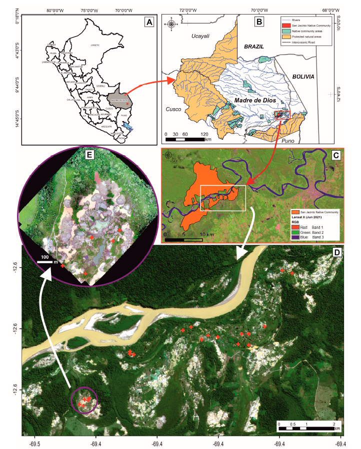

*Figure 1: Geographic location of the study area in Madre de Dios, Peru.*

## 3.3 Data Analysis

Statistical analyses included square root transformation of variables, hierarchical partitioning (R package *hier.part*), non-metric multidimensional scaling (nMDS), SIMPROF for floristic grouping, and distance-based redundancy analysis (dbRDA) with variance partitioning (*rdacca.hp* package). All analyses were conducted at a 5% significance level using R, SigmaPlot 15, and Primer v7.

# **4.Results**

```r
plants_df2 <- read.csv("f_data.csv")
head(plants_df2)
```

```
##   Plots Species_richness
## 1     1                3
## 2     2                7
## 3     3               10
## 4     4                3
## 5     5               15
## 6     6               18
```

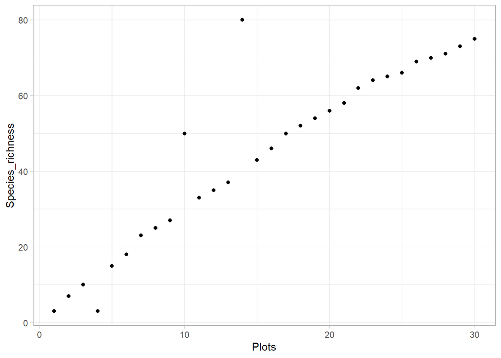

```r
View(plants_df2)

plants_df2_filtered <- na.omit(plants_df2)
library(ggplot2)


ggplot(plants_df2_filtered,aes(x=Plots,y=Species_richness))+
  geom_point()+
  theme_light()
```

Diameter distributions revealed an inverted-J pattern, with most individuals in the <5 cm DBH class; this proportion decreased over time, while larger size classes increased. Pioneer species (*Ochroma pyramidale*, *Cecropia membranacea*) dominated early abandonment plots, whereas later stages saw increased presence of *Ficus*, *Alchornea*, *Inga*, and *Croton*.

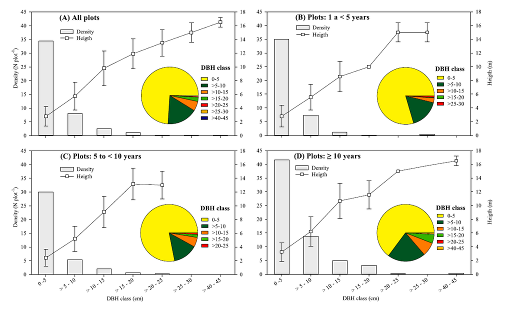

*Figure 3:The density and average height of individuals according to diameter categories of the vegetation in study areas. DBH = diameter at breast height*

HOF models showed that species responses varied with abandonment and distance to the forest edge: some decreased with distance, others increased with longer abandonment. ANOVA and correlation analyses confirmed that species richness, diversity, and basal area increased with abandonment time and decreased with distance from the forest. Seedling diversity was particularly sensitive to forest proximity, while tree abundance correlated positively with abandonment time. Regression models explained over 60% of variability in richness and abundance, with distance contributing more than abandonment.  
nMDS and dbRDA analyses indicated that floristic composition was structured by both abandonment time and distance to the forest edge, with distance exerting a stronger influence on community composition than abandonment time.

# **5.Conclusion**

Pioneer species dominate plots with short abandonment, while longer-abandoned plots show more advanced successional species. Natural regeneration after gold mining in San Jacinto is slow and depends on abandonment time and proximity to forest. Given high fragmentation, passive restoration is insufficient, and key species such as *Ochroma pyramidale*, *Ficus*, *Cecropia*, and *Inga* are recommended for active ecological restoration across the degraded areas.

# **Reference**

Y., Alarcon-Aguirre, G., Herrera-Machaca, M., Hilares Vargas, L., Corvera Gomringer, R., & del Castillo Torres, D. (2023). *Influence of Distance from Forest Edges on Spontaneous Vegetation Succession Following Small-Scale Gold Mining in the Southeast Peruvian Amazon.* **Diversity**, 15(6), 793. https://doi.org/10.3390/d15060793

# **My GitHub link**

[Link](https://github.com/amille25/r_markdown_anna_ass6)